# Ggplot2 Lab – a tribute to Hans Rosling

Marcin Kierczak

23 October 2016

Hans Rosling (27 July 1948 – 7 February 2017) was a Swedish physician, academic, statistician, and public speaker. He was the Professor of International Health at Karolinska Institutet and was the co-founder and chairman of the Gapminder Foundation, which developed the Trendalyzer software system. He held presentations around the world, including several TED Talks in which he promoted the use of data to explore development issues. [source: Wikipedia](https://en.wikipedia.org/wiki/Hans_Rosling)

# The Lab

In this excercise we will plot a Hans Rosling’s Gapminder-style plot using *ggplot2* library. It will not be as nice as the original, but it will be a good starting point for making more advanced graphics.

We have chosen to plot the so-called [Preston curve](https://en.wikipedia.org/wiki/Preston_curve), a curve reflecting life expectancy vs. *per capita* gross domestic product (GDP). To make the task more interesting, we will obtain the necessary data straight from Wikipedia, using a technique that is broadly called *web scraping*.

The first thing is to load a couple of packages that are necessary to do the analyses:

- rvest – will provide tools for harvesting (scraping) Wikipedia pages,
- stringr – will provide tools for string operations and it also imports the *magrittr* package that provides a nice new operator %>% called the pipe operator. More about it below,
- ggrepel – provides a mechanism of resolving overlapping text on ggplot2 plots,
- ggplot2 – for obvious reasons – plotting.
- plotly – provides a nice mechanism for generating interactive plots

```r
library(rvest)
library(stringr)
library(ggrepel)
library(ggplot2)
library(plotly)
```

Now, we need to import some data. Let’s start with GDP by country.

```r
# URL to the Wikipedia entry.
url <- "https://en.wikipedia.org/wiki/List_of_countries_by_GDP_(nominal)_per_capita"

# Use pipe operator to, in sequence, read  HTML source for the Wikipedia entry
# from the provided URL and fish-out all tables from there. The result, a list of
# tables will be assigned to variable data.
data <- url %>% read_html() %>% html_nodes('table')

# Now, just see what the data variable contains. We see, we want the 3rd table.
gdp <- html_table(data[[3]], dec='.', header=T)
# Remove commas and treat as numeric
gdp[,3] <- as.numeric(gsub(',', '', gdp[,3]))
# Country names are a bit messy due to encoding, we fix this with the iconv
# function.
gdp$Country <- iconv(gdp$Country, "UTF-8", "ascii", sub='')

# Remove any footnotes/remarks next to the country name. They are in either square or
# within the regular braces.
gdp$Country <- gsub('\\[.*\\]','', gdp$Country) %>% gsub('\\(.*\\)','', .)

# Name all the rows by the country.
rownames(gdp) <- gdp$Country

# Rename the 3rd column for the sake of simplicity.
colnames(gdp)[3] <- 'GDP'
```

Note the function of the *%>%* (pipe) operator. The **left() %>% right() -> var2** is equivalent to two lines of code:

```r
var1 <- left()
var2 <- right(var1)
```

You simply feed the result returned by the function to the left to the input of the function to the right.

Now, we would like to get some more data: life expectancy, population figure for each country and also the continent. We can than represent each country as a point on the plot with coords corresponding to GDP and life expectancy, the size of the point proportional to the population in millions and the colour of the point representing the continent. As GDP varies a lot, we will use logarythmic scale instead of the actual values. This will improve (hopefully) the readability.

```r
url <- "https://en.wikipedia.org/wiki/List_of_countries_by_life_expectancy"
data <- url %>% read_html() %>% html_nodes('table')
life.exp <- html_table(data[[1]], dec='.', header=T)
life.exp$Country <- iconv(life.exp$Country, "UTF-8", "ascii",sub='')
colnames(life.exp) <- gsub('\n', '', colnames(life.exp))
life.exp$Country <- gsub('\\[.*\\]','', life.exp$Country) %>% gsub('\\(.*\\)','', .)

url <- 'https://en.wikipedia.org/wiki/List_of_countries_and_dependencies_by_population'
data <- url %>% read_html() %>% html_nodes('table')
pop <- html_table(data[[2]], dec='.', header=T)
pop$`Country (or dependent territory)` <- iconv(pop$`Country (or dependent territory)`, "UTF-8", "ascii",sub='')
colnames(pop) <- gsub('\n', '', colnames(pop))
colnames(pop)[2] <- 'Country'
pop$Population <- as.numeric(gsub(',', '', pop$Population))
pop$Country <- gsub('\\[.*\\]','', pop$Country) %>% gsub('\\(.*\\)','', .)

# Continent
url <- 'https://en.wikipedia.org/wiki/List_of_sovereign_states_and_dependent_territories_by_continent'
data <- url %>% read_html() %>% html_nodes('table')
africa <- data.frame(continent="Africa", Country=html_table(data[[4]], dec='.', header=T)[,2])
asia <- data.frame(continent="Asia", Country=html_table(data[[6]], dec='.', header=T)[,2])
europe <- data.frame(continent="Europe", Country=html_table(data[[8]], dec='.', header=T)[,2])
americaNC <- data.frame(continent="North/Central America", Country=html_table(data[[10]], dec='.', header=T)[,2])
americaS <- data.frame(continent="South America", Country=html_table(data[[12]], dec='.', header=T)[,2])
ausocean <- data.frame(continent="Australia & Oceania", Country=html_table(data[[14]], dec='.', header=T)[,2])
continents <- rbind(africa, asia, europe, americaNC, americaS, ausocean)
continents$Country <- gsub('\\[.*\\]','', continents$Country) %>% gsub('\\(.*\\)','', .)
rownames(continents) <- continents$Country
```

Now, that we have all the data, we can merge them into a data frame that we will feed to ggplot:

```r
# Merge all data
dat <- merge(gdp[,c(2:3)], life.exp[,c(1,5,7,9)], by='Country')
dat <- merge(dat, pop[,c('Country', 'Population')], by='Country')
dat$continent <- continents[dat$Country,1]

labels <- paste('Population', dat$Population/1e6, 'million', sep = ' ')
dat2 <- data.frame(Country=dat$Country, GDP=dat$GDP, Life_expectancy=dat$`Both sexes lifeexpectancy (HALE)`, Population=dat$Population, Continent=dat$continent, text=labels)
```

Finally, time to plot…

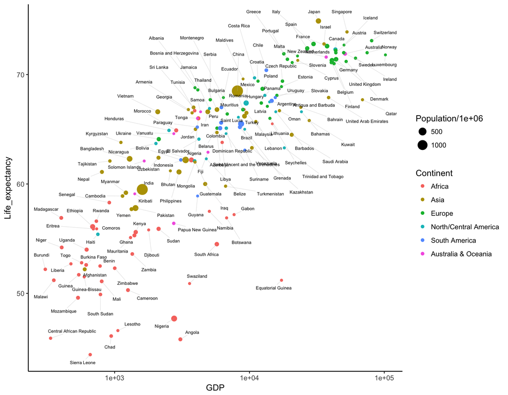

```r
g <- ggplot(dat2, aes(x=GDP, y=Life_expectancy,
                      label=Country, text=text, size=Population/1e6)) +
  geom_point(aes(col=Continent)) +
  geom_text_repel(size=2, box.padding = unit(0.5, "lines"), force=1,
                  segment.size = .1, segment.color = 'grey', max.iter = 100) +
  scale_x_log10() +
  theme_classic()
g
```

So far so good, but… there are some countries missing, e.g. USA. Why? Well, type:

```r
setdiff(gdp$Country, life.exp$Country)
```

[output not shown]

Some countries have different names in different Wikipedia tables. We could fix this manually, but we also can make use of an excellent package *gapminder* that provides us with all necessary data up to year 2007. Let us try:

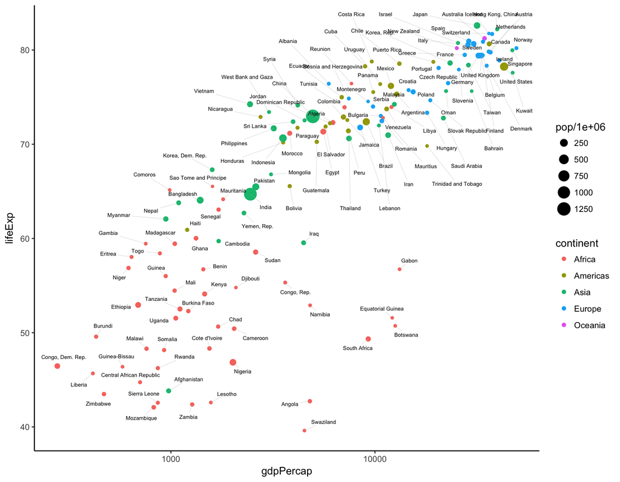

```r
library(gapminder)
gdata <- gapminder[gapminder$year==2007, ]
g <- ggplot(gdata, aes(x=gdpPercap, y=lifeExp, label=country)) +
  geom_point(aes(col=continent, size=pop/1e6)) +
  geom_text_repel(size=2, box.padding = unit(0.5, "lines"), force=1,
                  segment.size = .1, segment.color = 'grey', max.iter = 100) +
  scale_x_log10() +
  theme_classic()
g
```

And now, make an interactive plot with plotly. Have fun!

```r
plotly <- ggplotly(g, tooltip=c('country', 'x', 'y', 'col'), )
plotly
```

[interactive chart not shown]